# Employment Model: Model Selection and Implementation

Author

Group 5

Published

October 4, 2026

## Run this if you need the packages

```r
# Only needed if the packages are not installed yet:
# install.packages(c("tidyverse", "survey", "rpart", "rpart.plot", "ranger"))
```

## About this file

This file covers the “Modelling strategy and technique selection” and “Model implementation and reproducibility” for the **employment question** (research areas B and C). This notebook chooses the candidate models, explains why each one was chosen and fits them to the training data.

Tuning and evaluation are done in a separate notebook. This file therefore **does not use the test set**, does not tune any parameters and does not calculate performance metrics. It fits each model once with documented starting parameters and saves it to `Models/`, so the evaluation notebook can load the models, tune them with household-grouped cross-validation and test them. The income question (research area D) is modelled in `3.2) Income Model.qmd`. The reasoning behind each model is also written up in `Milestone 3 Submit.docx` (in `Documentation/Milestone Documentation/Milestone 3/`).

## How this notebook works

1. **Load the shared setup** with `source("R/model_preparation.R")`. This gives the notebook the predictor lists, the model formulas and `prepare_employment_data()`. It has to be loaded in every notebook, it basically just makes reusable code so that you do not have to run the same set of code over and over in each notebook you can just call the predictor lists and model formulas from inside that R Script.
2. **Prepare the training data** with `prepare_employment_data()`, which reads `model_train.csv` the same way in every notebook.
3. **Fit three models** each model is one function call that receives a formula, the training data and the model’s parameters. Each parameter is explained in a comment next to it.
4. **Save** each fitted model to is saved to `Models/` and check that it reloads with identical predictions.
5. `3.3) Model Evaluation.qmd` then tunes the saved models and tests them on the test set.

**What “fitting” means for each model:**

| Model | Function | What fitting does | What comes out |
| --- | --- | --- | --- |
| Logistic regression | `survey::svyglm()` | Finds the coefficient for each predictor that makes the observed employment outcomes most likely, using the survey weights | One odds ratio per predictor, including the education × internet interaction |
| Decision tree | `rpart::rpart()` | Repeatedly picks the predictor and cut-off that best separate employed from unemployed people, then does the same inside each group | A set of if-then rules |
| Random forest | `ranger::ranger()` | Grows 500 trees, each on a random resample of the people and choosing from a few random predictors at each split, and averages their predictions | Probabilities, and a ranking of how much each predictor is used |

### Formulas: `+` and `*`

A formula tells a model what to predict and from what: the outcome goes on the left of `~` and the predictors on the right, for example `employed ~ matric_plus + female`. The formulas are defined once, in `Scripts/R/model_preparation.R`. This means we predict employed, based on the columns matric_plus and female.

`matric_plus` and `any_home_internet` are both 0/1, so together they split people into four groups. Their employment rates in the training data are:

|  | No internet | Internet | What internet access adds |
| --- | --- | --- | --- |
| **Below matric** | 57.6% | 59.7% | +2.1 points |
| **Matric** | 58.1% | 69.9% | +11.8 points |

**With `+`** (`employed ~ matric_plus + any_home_internet`), each predictor gets **one effect that is the same for everyone**. The model describes the four groups with three numbers: a starting point (below matric, no internet), a matric step (moving down a row, the same in both columns) and an internet step (moving right a column, the same in both rows). Fitted to the rates above:

|  | No internet | Internet |
| --- | --- | --- |
| **Below matric** | 55.0 | 55.0 + 5.4 = 60.4 |
| **Matric** | 55.0 + 8.9 = 63.9 | 55.0 + 8.9 + 5.4 = 69.4 |

The internet step has to be +5.4 in both rows, a compromise between the real +2.1 and +11.8. A `+` model therefore cannot show that internet access goes with a bigger advantage for people with matric, which is exactly the question Treasury is asking.

**With `*`** (`employed ~ matric_plus * any_home_internet`), R adds both predictors **and** their interaction: it expands the formula to `matric_plus + any_home_internet + matric_plus:any_home_internet`. The interaction is a fourth number that applies **only to the group with both matric and internet access**, so every group gets its own value:

|  | No internet | Internet |
| --- | --- | --- |
| **Below matric** | 57.6 | 57.6 + 2.1 = 59.7 |
| **Matric** | 57.6 + 0.5 = 58.1 | 57.6 + 0.5 + 2.1 + **9.7** = 69.9 |

The fourth number (+9.7) is how much better the “both” group does than the matric step and the internet step added together. Above zero means education and internet access **reinforce** each other (complements); below zero means one **makes up for** the other (substitutes).

These tables use raw percentages without the other predictors, to show the idea. The logistic regression works the same way on the log-odds scale with all 13 controls included, where the interaction is reported as an odds ratio (above 1 = complements, below 1 = substitutes).

The logistic regression uses `*` for education × internet and `+` for every control. The tree and forest use `+` only, because a tree finds interactions itself by splitting on one variable inside a split on another.

## Loading the packages we need

```r
library(tidyverse)  # data handling (also loaded by the preparation script)
library(survey)     # svyglm(): logistic regression with survey weights and household clustering
library(rpart)      # decision tree
library(rpart.plot) # readable plot of the decision tree
library(ranger)     # random forest (a fast implementation of randomForest)
```

## File paths

```r
analytical_directory <- "../Datasets/Analytical/"
model_directory <- "../Models/"

dir.create(model_directory, showWarnings = FALSE) # created on the first run only
```

# 1. Analytical question and modelling task

The Milestone 1 analytics goal is to model employment status based on education level and connectivity. The National Treasury needs to know whether education and household internet access **reinforce** each other (the combination is associated with more employment than either one alone) or **substitute** for each other (one makes up for the lack of the other).

- **Modelling task:** binary **classification**. The target `employed` has two classes, Employed and Unemployed, for people in the labour force.
- **Population:** working-age people (15–64) in the labour force, from `model_train.csv`.
- **What the models must deliver:** an estimate of the education × internet interaction that can be read as an odds ratio, predicted employment probabilities for the deployed Shiny app, and a second, tree-based model to check the findings.

# 2. Data and predictors

## 2.1 Reading the training data

The data are read through `prepare_employment_data()` in `Scripts/R/model_preparation.R`. The evaluation notebook and the Shiny app use the same function, so every file is prepared in exactly the same way. The function:

1. reads `household_id` as text (it is 18 digits long and would otherwise be rounded),
2. applies fixed category levels, with the reference levels from the Milestone 2 data dictionary,
3. leaves out the people with Other/unknown education, who have no `matric_plus` value, and
4. keeps the design columns, the target and the 15 chosen predictors.

```r
source("R/model_preparation.R")

# Raw file, only to count the rows before preparation
model_train_raw <- read_csv(
  file.path(analytical_directory, "model_train.csv"),
  col_types = cols(household_id = col_character()),
  show_col_types = FALSE
)

model_train <- prepare_employment_data(file.path(analytical_directory, "model_train.csv"))
```

```r
tibble(
  check = c(
    "Rows in model_train.csv",
    "Rows removed: Other/unknown education (matric_plus blank)",
    "Rows used for model fitting",
    "Households used for model fitting",
    "Missing values left in the predictors or target",
    "Category values that did not match the fixed levels"
  ),
  value = c(
    nrow(model_train_raw),
    sum(is.na(model_train_raw$matric_plus)),
    nrow(model_train),
    n_distinct(model_train$household_id),
    sum(is.na(select(model_train, -household_id, -person_weight))),
    # a value outside the fixed levels would have become NA in apply_category_levels()
    sum(is.na(model_train$population_group) | is.na(model_train$province) |
        is.na(model_train$settlement_type) | is.na(model_train$smartphone_access) |
        is.na(model_train$other_member_matric))
  )
)
```

| check | value |
| --- | --- |
| Rows in model_train.csv | 23041 |
| Rows removed: Other/unknown education (matric_plus blank) | 370 |
| Rows used for model fitting | 22671 |
| Households used for model fitting | 13298 |
| Missing values left in the predictors or target | 0 |
| Category values that did not match the fixed levels | 0 |

```r
model_train |> count(employed) |> mutate(share = round(n / sum(n), 3))
```

| employed | n | share |
| --- | --- | --- |
| Unemployed | 8016 | 0.354 |
| Employed | 14655 | 0.646 |

Removing the people with unknown education does not change the class balance noticeably: about 65% are employed, as in Milestone 2. The imbalance of roughly 2:1 is mild, so all three models are fitted on the data as they are, without resampling. How the Unemployed class is handled at prediction time (the classification threshold) is part of tuning and evaluation.

## 2.2 Choosing the predictors

`model_data.csv` has 21 candidate predictors, several of which measure the same thing in different ways. Using overlapping columns together would split one effect across several coefficients and make the interaction harder to read, so one version of each idea is kept:

| Kept | Left out | Reason |
| --- | --- | --- |
| `matric_plus` (0/1) | `education_band` | The business question is framed as “with or without matric”. A 0/1 variable gives the interaction **one** odds ratio instead of six (one per education band), which answers the question directly. `educ… |
| `any_home_internet` (0/1) | `has_fixed_internet`, `has_mobile_internet`, `digital_access_score` | Internet access is the policy lever (connectivity subsidies). The fixed and mobile columns are its parts, and `digital_access_score` adds them to computer and smartphone access, so any of them next to… |
| `has_computer`, `smartphone_access` |  | Kept as separate controls for other kinds of digital access, so that the internet effect is not simply picking up device ownership (which also reflects household wealth). |
| `matric_plus × any_home_internet` (in the regression formula) | `edu_digital_group` | `edu_digital_group` is the same combination stored as one categorical column. Using both would duplicate the interaction. |
| `household_size`, `n_children_under15`, `elderly_in_household`, `female_x_children`, `other_member_matric` | `dependency_ratio` | `dependency_ratio` is calculated from the number of children, elderly and working-age members, which the other household columns already describe. |
| `age_centred`, `age_centred_squared`, `female`, `population_group`, `province`, `settlement_type` |  | Standard labour-market controls. Without them, the internet effect would partly be an age, location or population-group effect. `population_group` is a sensitive attribute: it is included **as a contr… |

`household_id` and `person_weight` are design columns and never predictors: `household_id` defines the clusters and `person_weight` is the survey weight.

The correlations between the numeric household predictors are checked below, because strongly correlated predictors make regression coefficients unstable:

```r
model_train |>
  select(household_size, n_children_under15, elderly_in_household, female_x_children,
         age_centred, age_centred_squared) |>
  cor() |>
  round(2)
```

```
                     household_size n_children_under15 elderly_in_household
household_size                 1.00               0.81                 0.26
n_children_under15             0.81               1.00                 0.11
elderly_in_household           0.26               0.11                 1.00
female_x_children              0.56               0.72                 0.07
age_centred                   -0.15              -0.12                -0.05
age_centred_squared            0.08              -0.01                 0.01
                     female_x_children age_centred age_centred_squared
household_size                    0.56       -0.15                0.08
n_children_under15                0.72       -0.12               -0.01
elderly_in_household              0.07       -0.05                0.01
female_x_children                 1.00       -0.08               -0.03
age_centred                      -0.08        1.00               -0.15
age_centred_squared              -0.03       -0.15                1.00
```

The highest correlation is between `household_size` and `n_children_under15` (about 0.8). Both are controls rather than the effects of interest, so both are kept. The education and internet columns are not affected.

Each combination of matric and internet access must also contain enough people to estimate the interaction reliably:

```r
model_train |>
  count(matric_plus, any_home_internet, employed) |>
  pivot_wider(names_from = employed, values_from = n) |>
  mutate(total = Unemployed + Employed)
```

| matric_plus | any_home_internet | Unemployed | Employed | total |
| --- | --- | --- | --- | --- |
| 0 | 0 | 981 | 1331 | 2312 |
| 0 | 1 | 3089 | 4567 | 7656 |
| 1 | 0 | 426 | 590 | 1016 |
| 1 | 1 | 3520 | 8167 | 11687 |

The smallest group, people with matric but no home internet, still has more than 1,000 people, so all four combinations can be estimated.

# 3. Candidate models

Three models are fitted. They are chosen to answer the question in different ways, not only to compete on accuracy:

| Model | Package | Role | Why it suits this problem |
| --- | --- | --- | --- |
| **1. Survey-weighted logistic regression** | `survey::svyglm()` | Main explanatory model | The only candidate that estimates the education × internet interaction directly as an odds ratio with a significance test, as the Milestone 1 success criteria require. It uses the survey weights and a… |
| **2. Decision tree** | `rpart::rpart()` | Interpretable tree-based check | Finds interactions itself, without being told about them. If it splits on internet access differently for people with and without matric, that supports the regression’s interaction. Its rules are easy… |
| **3. Random forest** | `ranger::ranger()` | Predictive benchmark | Captures non-linear effects and interactions that the regression’s form rules out. Shows how much predictive power the simpler models give up, and whether education and internet remain important once … |

Models 2 and 3 are both tree-based but play different roles: the tree is readable, and the forest is accurate but hard to read.

Models considered but not used:

- **Penalised logistic regression (lasso/ridge):** useful when there are many predictors. With 15 chosen predictors and more than 20,000 rows, a standard logistic regression is stable, and penalisation would shrink the interaction coefficient that the question is about.
- **k-nearest neighbours, support vector machines, neural networks:** they give no interpretable effect sizes, and k-NN and SVMs need scaled numeric inputs, which the categorical predictors here do not suit.
- **Clustering:** the question has a known target (`employed`), so a supervised model is more appropriate.

All three models are fitted to the same training rows with the same predictors, so the evaluation notebook can compare them fairly.

# 4. Model 1: Survey-weighted logistic regression

## 4.1 Assumptions and parameter choices

Logistic regression models the log-odds of being employed as a linear combination of the predictors. Its assumptions and how each one is handled:

| Assumption | How it is handled |
| --- | --- |
| Binary outcome | `employed` has two levels, with Unemployed as the reference, so the model predicts the probability of being **Employed**. |
| Independent observations | People in the same household are not independent: they share every household-level predictor. The survey design treats **households as clusters**, so the standard errors (and the p-value of the intera… |
| Log-odds linear in the numeric predictors | Age has a curved relationship with employment (low for the young, highest in mid-career), so `age_centred_squared` is included next to `age_centred`. |
| No strong multicollinearity | Overlapping predictors were removed in preprocessing, and the remaining correlations are acceptable. |
| Enough cases for each parameter | About 8,000 unemployed people for fewer than 35 coefficients, far above the usual minimum of 10–20 events per coefficient. |
| Representative estimates | Stats SA gives each person a `person_weight` because some groups were sampled more heavily than others. Weighting the model makes the odds ratios describe the South African labour force rather than th… |

Parameter choices:

- `family = quasibinomial()`: the logistic link, as in a standard logistic regression. `svyglm()` uses the quasi-binomial family with survey weights because the weighted counts are not whole numbers. The coefficients are identical to `binomial()`.
- Design: `ids = ~household_id` (clusters) and `weights = ~person_weight`.
- The interaction is written `matric_plus * any_home_internet`, which adds both main effects and their product. The product’s coefficient, as an odds ratio, is the answer to the complements-or-substitutes question: **above 1** means internet goes with a larger employment advantage for people with matric (complements), **below 1** means a smaller one (substitutes).

There are no hyperparameters to tune in this model.

## 4.2 Fitting the model

```r
# Survey design: tells svyglm() how the sample was drawn
employment_design <- svydesign(
  ids = ~household_id,      # clusters: household members share household predictors, so they are not independent
  weights = ~person_weight, # survey weight: how many people in the population each row represents
  data = model_train
)

employment_logistic <- svyglm(
  employment_regression_formula, # employed ~ matric_plus * any_home_internet + the 13 controls (R/model_preparation.R)
  design = employment_design,    # the data, weights and clusters defined above
  family = quasibinomial()       # logistic regression for a yes/no outcome; "quasi" allows non-whole weighted counts
)

employment_regression_formula # prints the formula in full
```

```
employed ~ matric_plus * any_home_internet + has_computer + smartphone_access +
    age_centred + age_centred_squared + female + population_group +
    province + settlement_type + household_size + n_children_under15 +
    elderly_in_household + female_x_children + other_member_matric
```

## 4.3 Fitted coefficients

The table converts each coefficient into an odds ratio with a 95% confidence interval. This is the fitted model itself interpreting it against the business objectives is part of evaluation.

```r
coefficient_table <- summary(employment_logistic)$coefficients
confidence_limits <- confint(employment_logistic) # Wald intervals, using the clustered standard errors

tibble(
  term = rownames(coefficient_table),
  odds_ratio = exp(coefficient_table[, "Estimate"]),
  ci_lower = exp(confidence_limits[, 1]),
  ci_upper = exp(confidence_limits[, 2]),
  p_value = coefficient_table[, "Pr(>|t|)"]
) |>
  mutate(across(odds_ratio:ci_upper, \(x) round(x, 3)),
         p_value = format.pval(p_value, digits = 3, eps = 0.0001)) # very small p-values show as "<1e-04"
```

| term | odds_ratio | ci_lower | ci_upper | p_value |
| --- | --- | --- | --- | --- |
| (Intercept) | 1.859 | 1.558 | 2.220 | < 1e-04 |
| matric_plus | 1.148 | 0.952 | 1.383 | 0.147646 |
| any_home_internet | 1.103 | 0.942 | 1.291 | 0.223706 |
| has_computer | 1.832 | 1.643 | 2.043 | < 1e-04 |
| smartphone_accessFewer than 1 per member | 1.355 | 1.143 | 1.607 | 0.000477 |
| smartphone_access1 or more per member | 2.163 | 1.808 | 2.587 | < 1e-04 |
| age_centred | 1.056 | 1.052 | 1.060 | < 1e-04 |
| age_centred_squared | 0.998 | 0.998 | 0.998 | < 1e-04 |
| female | 0.742 | 0.672 | 0.819 | < 1e-04 |
| population_groupColoured | 1.381 | 1.158 | 1.646 | 0.000325 |
| population_groupIndian/Asian | 3.075 | 2.039 | 4.637 | < 1e-04 |
| population_groupWhite | 3.317 | 2.431 | 4.525 | < 1e-04 |
| provinceWestern Cape | 1.547 | 1.305 | 1.833 | < 1e-04 |
| provinceEastern Cape | 1.065 | 0.916 | 1.237 | 0.412193 |
| provinceNorthern Cape | 0.976 | 0.776 | 1.228 | 0.835764 |
| provinceFree State | 0.729 | 0.618 | 0.861 | 0.000196 |
| provinceKwaZulu-Natal | 0.994 | 0.865 | 1.142 | 0.931396 |
| provinceNorth West | 1.236 | 1.027 | 1.488 | 0.025328 |
| provinceMpumalanga | 0.886 | 0.756 | 1.039 | 0.137176 |
| provinceLimpopo | 1.366 | 1.151 | 1.621 | 0.000356 |
| settlement_typeNon-metro urban | 1.134 | 1.012 | 1.271 | 0.030932 |
| settlement_typeTraditional | 0.663 | 0.580 | 0.757 | < 1e-04 |
| settlement_typeFarms | 1.637 | 1.307 | 2.051 | < 1e-04 |
| household_size | 0.911 | 0.876 | 0.948 | < 1e-04 |
| n_children_under15 | 1.152 | 1.073 | 1.236 | < 1e-04 |
| elderly_in_household | 0.693 | 0.606 | 0.792 | < 1e-04 |
| female_x_children | 0.913 | 0.866 | 0.963 | 0.000751 |
| other_member_matricYes | 0.978 | 0.894 | 1.071 | 0.631305 |
| other_member_matricNo other working-age member | 1.451 | 1.276 | 1.649 | < 1e-04 |
| matric_plus:any_home_internet | 1.292 | 1.057 | 1.580 | 0.012476 |

Basic fitting checks: every training row was used, and no coefficient is missing or unusually large (a sign of perfect separation):

```r
tibble(
  check = c("Rows used in the fit", "Coefficients estimated", "Coefficients not estimated (NA)",
            "Largest absolute coefficient"),
  value = c(
    nobs(employment_logistic),
    length(coef(employment_logistic)),
    sum(is.na(coef(employment_logistic))),
    round(max(abs(coef(employment_logistic)), na.rm = TRUE), 2)
  )
)
```

| check | value |
| --- | --- |
| Rows used in the fit | 22671.0 |
| Coefficients estimated | 30.0 |
| Coefficients not estimated (NA) | 0.0 |
| Largest absolute coefficient | 1.2 |

# 5. Model 2: Decision tree

## 5.1 Assumptions and parameter choices

A classification tree repeatedly splits the data on the predictor and cut-off that best separate employed from unemployed people, and predicts the share of employed people in each final group (leaf). It makes no assumptions about linearity or the shape of the effects, and it uses the categorical predictors directly without dummy columns.

Starting parameters (to be tuned in the evaluation notebook):

| Parameter | Value | Reason |
| --- | --- | --- |
| `method` | `"class"` | Classification tree for the two-level target. |
| `maxdepth` | 5 | At most five questions from the top of the tree to a prediction. A tree deeper than that is no longer readable, and being readable is why a tree was chosen. |
| `minbucket` | 100 | Every leaf describes at least 100 people (about 0.4% of the training data). This keeps the leaves stable, and it avoids rules that describe very small, possibly identifiable groups. |
| `cp` | 0.001 | A split is kept if it improves the fit by at least 0.1%. This is low on purpose: `maxdepth` and `minbucket` limit the size, and pruning is left to tuning. |
| `xval` | 0 | rpart’s built-in cross-validation is switched off. It splits by person, which would put members of the same household on both sides and overstate performance. Tuning uses household-grouped cross-valid… |

**Survey weights are not used in the tree.** The weights range from 50 to 5,531, so a weighted tree would let a small number of heavily weighted people decide the splits. The tree’s job is to check whether the same pattern appears without the regression’s assumptions, not to produce population estimates, which Model 1 does. The evaluation notebook can still report weighted performance metrics.

## 5.2 Fitting the model

```r
set.seed(67) # Same seed as the train/test split, for reproducibility

employment_tree <- rpart(
  employment_tree_formula,
  data = model_train,
  method = "class",
  control = rpart.control(
    maxdepth = 5,
    minbucket = 100,
    cp = 0.001,
    xval = 0
  )
)
```

## 5.3 Fitted tree

Each box shows the predicted probability of being employed and the share of training people who end up in that box:

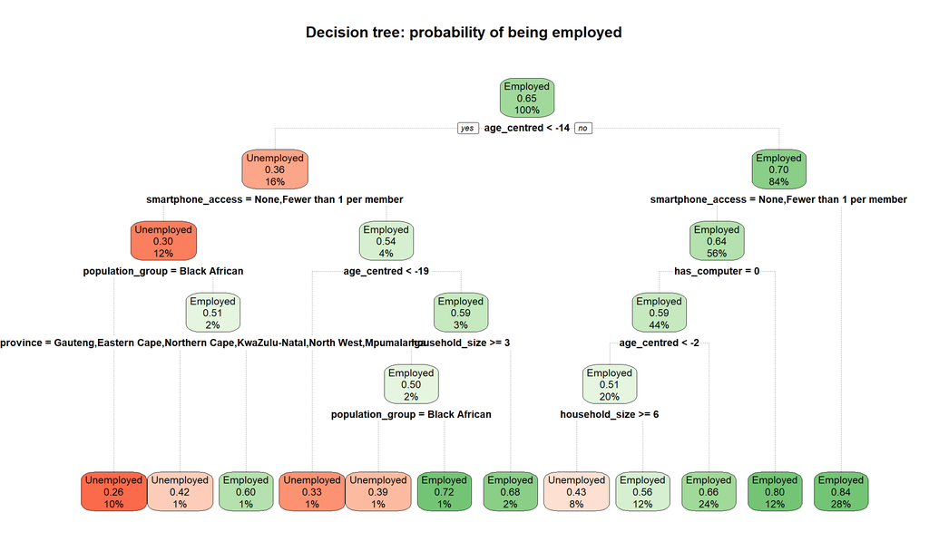

```r
rpart.plot(
  employment_tree,
  extra = 106,         # probability of the second class (Employed) + percentage of people
  box.palette = "RdGn",
  branch.lty = 3,
  tweak = 1.1,
  main = "Decision tree: probability of being employed"
)
```

```r
tibble(
  measure = c("Leaves (final groups)", "Splits", "Predictors used in at least one split"),
  value = c(
    sum(employment_tree$frame$var == "<leaf>"),
    sum(employment_tree$frame$var != "<leaf>"),
    n_distinct(employment_tree$frame$var[employment_tree$frame$var != "<leaf>"])
  )
)
```

| measure | value |
| --- | --- |
| Leaves (final groups) | 12 |
| Splits | 11 |
| Predictors used in at least one split | 6 |

# 6. Model 3: Random forest

## 6.1 Assumptions and parameter choices

A random forest grows many decision trees, each on a bootstrap sample of the training data and each considering only a random subset of the predictors at every split, and averages their predictions. Averaging many different trees gives more accurate and more stable predictions than one tree, at the cost of not being readable. Like the tree, it assumes no functional form and finds interactions itself.

`ranger` is used instead of `randomForest` because it gives the same algorithm much faster and handles categorical predictors better.

Starting parameters (to be tuned in the evaluation notebook):

| Parameter | Value | Reason |
| --- | --- | --- |
| `num.trees` | 500 | Enough trees for the predictions and the importance scores to stabilise. More trees only cost time. |
| `mtry` | 3 | Predictors considered at each split: the standard √15 ≈ 3 for classification. The main tuning parameter. |
| `min.node.size` | 10 | The standard minimum leaf size for probability forests. |
| `probability` | `TRUE` | Predicts the probability of being employed rather than a class, so the evaluation notebook can pick the threshold and calculate ROC-AUC. |
| `respect.unordered.factors` | `"order"` | Orders the levels of each categorical predictor (for example the nine provinces) by their share of employed people before splitting. Otherwise ranger treats the levels as ordered in their alphabetical… |
| `importance` | `"permutation"` | Measures how much the predictions worsen when a predictor’s values are shuffled. More reliable than impurity importance, which favours predictors with many levels. |
| `seed` | 67 | Makes the bootstrap samples, and so the forest, reproducible. |

Survey weights are not used, for the same reason as the tree: in `ranger`, weights change how often each person is drawn into the bootstrap samples, so the most heavily weighted people would appear in almost every tree.

## 6.2 Fitting the model

```r
# household_id and person_weight are not in the formula, so they are not used
employment_forest <- ranger(
  employment_tree_formula,
  data = model_train,
  num.trees = 500,
  mtry = 3,
  min.node.size = 10,
  probability = TRUE,
  respect.unordered.factors = "order",
  importance = "permutation",
  seed = 67
)
```

## 6.3 Variable importance

The forest has no coefficients. The permutation importance shows which predictors it relies on most:

```r
tibble(
  predictor = names(importance(employment_forest)),
  permutation_importance = importance(employment_forest)
) |>
  arrange(desc(permutation_importance)) |>
  mutate(permutation_importance = signif(permutation_importance, 3))
```

| predictor | permutation_importance |
| --- | --- |
| age_centred | 0.04010 |
| household_size | 0.02270 |
| smartphone_access | 0.01600 |
| age_centred_squared | 0.01110 |
| n_children_under15 | 0.01010 |
| has_computer | 0.00905 |
| province | 0.00747 |
| settlement_type | 0.00746 |
| population_group | 0.00701 |
| matric_plus | 0.00649 |
| female_x_children | 0.00616 |
| other_member_matric | 0.00591 |
| elderly_in_household | 0.00404 |
| female | 0.00388 |
| any_home_internet | 0.00259 |

Importance shows how much the forest *uses* a predictor, not the direction of its effect and not a causal effect.

# 7. Saving the models and handing over to evaluation

The three fitted models are saved to `Models/`:

```r
saveRDS(employment_logistic, file.path(model_directory, "employment_logistic.rds"))
saveRDS(employment_tree, file.path(model_directory, "employment_tree.rds"))
saveRDS(employment_forest, file.path(model_directory, "employment_forest.rds"))

tibble(
  file = c("employment_logistic.rds", "employment_tree.rds", "employment_forest.rds"),
  size_mb = round(file.size(file.path(model_directory, file)) / 1024^2, 1)
)
```

| file | size_mb |
| --- | --- |
| employment_logistic.rds | 7.0 |
| employment_tree.rds | 0.0 |
| employment_forest.rds | 13.7 |

The models are read back to confirm that they load and give the same predictions as the models in memory:

```r
check_rows <- head(model_train, 20)

tibble(
  model = c("Logistic regression", "Decision tree", "Random forest"),
  predictions_identical = c(
    identical(
      as.numeric(predict(employment_logistic, check_rows, type = "response")),
      as.numeric(predict(readRDS(file.path(model_directory, "employment_logistic.rds")),
                         check_rows, type = "response"))
    ),
    identical(
      predict(employment_tree, check_rows, type = "prob"),
      predict(readRDS(file.path(model_directory, "employment_tree.rds")), check_rows, type = "prob")
    ),
    identical(
      predict(employment_forest, check_rows)$predictions,
      predict(readRDS(file.path(model_directory, "employment_forest.rds")), check_rows)$predictions
    )
  )
)
```

| model | predictions_identical |
| --- | --- |
| Logistic regression | TRUE |
| Decision tree | TRUE |
| Random forest | TRUE |

## Handover to tuning and evaluation

**Preparing the test set.** Use the same function, so the test set gets the same rows, columns and factor levels:

```r
source("R/model_preparation.R")
model_test <- prepare_employment_data("../Datasets/Analytical/model_test.csv")
```

**Getting predicted probabilities of being Employed** from each saved model:

```r
employment_logistic <- readRDS("../Models/employment_logistic.rds")
employment_tree     <- readRDS("../Models/employment_tree.rds")
employment_forest   <- readRDS("../Models/employment_forest.rds")

p_logistic <- as.numeric(predict(employment_logistic, model_test, type = "response"))
p_tree     <- predict(employment_tree, model_test, type = "prob")[, "Employed"]
p_forest   <- predict(employment_forest, model_test)$predictions[, "Employed"]
```

Points to keep the tuning free of leakage:

- Cross-validate **by household**, for example `caret::groupKFold(model_train$household_id, k = 5)`, for the same reason the train/test split was grouped by household. rpart’s own `xval` splits by person and should stay switched off.
- Choose the tuned parameters and the threshold on the **training folds only**, then use `model_test` once, for the final comparison.
- `person_weight` can be passed to the metrics to report population-weighted performance next to the unweighted figures.